# Lab 4 - Linear Regression Contd.

```r
library(tidyverse)
library(ggplot2)
library(summarytools)
library(jtools)
library(naniar)
library(fastDummies)
library(knitr)
```

In this lab we will try to use the csiw dataset but with different variable to understand how this analysis is to be done.

Let us load the required libraries first

[output not shown]

Let us see how this dataset looks

```r
summary(csiw, plain.ascii = FALSE)
```

```
##      school          teacher            id            group
##  Min.   : 1.000   Min.   : 1.00   Min.   : 1.00   Min.   :-9.000
##  1st Qu.: 1.000   1st Qu.: 4.00   1st Qu.:20.00   1st Qu.: 1.000
##  Median : 2.000   Median : 8.00   Median :35.00   Median : 2.000
##  Mean   : 4.509   Mean   :10.91   Mean   :32.12   Mean   : 1.514
##  3rd Qu.: 9.000   3rd Qu.:18.00   3rd Qu.:44.00   3rd Qu.: 4.000
##  Max.   :13.000   Max.   :55.00   Max.   :61.00   Max.   : 4.000
##
##     treatmt           cch1              cch2             ccpt1
##  Min.   :1.000   Min.   :-9.0000   Min.   :-9.0000   Min.   :-9.000
##  1st Qu.:1.000   1st Qu.: 0.0000   1st Qu.: 0.5000   1st Qu.: 0.000
##  Median :1.000   Median : 1.0000   Median : 1.0000   Median : 5.000
##  Mean   :1.302   Mean   :-0.8305   Mean   :-0.4619   Mean   : 3.101
##  3rd Qu.:2.000   3rd Qu.: 2.0000   3rd Qu.: 2.0000   3rd Qu.: 8.000
##  Max.   :2.000   Max.   : 3.0000   Max.   : 3.0000   Max.   :16.000
##
##      ccpt2           ccprod1         ccprod2           ccrdr1
##  Min.   :-9.000   Min.   :-9.00   Min.   :-9.000   Min.   :-9.000
##  1st Qu.: 3.000   1st Qu.: 0.00   1st Qu.: 1.000   1st Qu.: 0.000
##  Median : 7.000   Median : 2.00   Median : 4.000   Median : 0.000
##  Mean   : 5.098   Mean   : 1.41   Mean   : 2.143   Mean   :-1.052
##  3rd Qu.:11.000   3rd Qu.: 5.00   3rd Qu.: 6.000   3rd Qu.: 1.000
##  Max.   :15.000   Max.   :17.00   Max.   :19.000   Max.   : 8.000
##
##      ccrdr2            grade           hotistdum
##  Min.   :-9.0000   Min.   :-9.0000   Min.   :0.0000
##  1st Qu.: 0.0000   1st Qu.: 1.0000   1st Qu.:0.0000
##  Median : 0.0000   Median : 1.0000   Median :1.0000
##  Mean   : 0.1646   Mean   : 0.4423   Mean   :0.6196
##  3rd Qu.: 2.0000   3rd Qu.: 2.0000   3rd Qu.:1.0000
##  Max.   :12.0000   Max.   : 2.0000   Max.   :1.0000
##                                      NA's   :81
```

Keeping in line with the assignment structure we will choose the following variables

1. Treatment variable (binary) - `treatmt`
2. Achievement level (4 categories and extra category for missing data) - `group`
3. Pretest variable - `ccrdr1`
4. Post test variable - `ccrdr2`
5. Grade (1=Grade 4, 2= Grade 5) - `grade`

Now let us subset this information into a dataset and analyze

```r
csiw <- csiw %>% dplyr::transmute(treat=treatmt, group=group, pretest = ccrdr1, posttest=ccrdr2, grade =grade)
```

We have two recoding tasks ahead of us.

1. Recoding achievement levels in the `group` variable. But this is essentially creating dummy variables which is a little bit different than simple recoding. For creation of dummies we will use a convenient R package called `fastDummies`.
2. Recoding grade level in the `grade` variable. For this we will use the recode function in `dplyr` package.

How does the achievement level variable actuall look

```r
table(csiw$group)
```

```
##
##  -9   1   2   3   4
##  40  84  82  76 125
```

Other than the four categories of relevant levels, we also have a `-9` for the missing data. While there are many ways to deal with missing data such as mean/median/mode substitution or multiple imputation techniques among others. In our analysis, we will simply drop the data under the assumption of **Missing at Random**. It simple means that once we control for the relevant confounders, the data can be assumed to be missing at random and hence dropping those observations will not create bias in our estimates.

Therefore, we will replace the `-9` with NAs. We will be using a powerful package called `naniar` to deal with missing values.

```r
#install.packages("naniar")
library(naniar)

csiw <- csiw %>% replace_with_na(replace = list(group = -9))
```

We can also do this for the remaning variables in the dataset

```r
csiw <- csiw %>% replace_with_na(replace=list(pretest=-9,posttest=-9, grade=-9))
```

Now that we have dealt with the missing data, let us move onto the recoding process for `group` and `grade`. But remember…

```
Variable to be recoded has to be a Factor Variable.
```

Are our variables of interest in the factor type?

```r
class(csiw$treat)
```

```
## [1] "numeric"
```

```r
class(csiw$group)
```

```
## [1] "numeric"
```

```r
class(csiw$grade)
```

```
## [1] "numeric"
```

```r
table(csiw$treat)
```

```
##
##   1   2
## 284 123
```

```r
table(csiw$group)
```

```
##
##   1   2   3   4
##  84  82  76 125
```

```r
table(csiw$grade)
```

```
##
##   1   2
## 194 173
```

So let us convert them to factors first

```r
csiw$treat <- as.factor(csiw$treat)
csiw$treat <- factor(as.numeric(as.character(csiw$treat)), ordered=FALSE)



csiw$group <- as.factor(csiw$group)
csiw$grade <- as.factor(csiw$grade)

class(csiw$treat)
```

```
## [1] "factor"
```

```r
class(csiw$group)
```

```
## [1] "factor"
```

```r
class(csiw$grade)
```

```
## [1] "factor"
```

```r
table(csiw$treat)
```

```
##
##   1   2
## 284 123
```

```r
table(csiw$group)
```

```
##
##   1   2   3   4
##  84  82  76 125
```

```r
table(csiw$grade)
```

```
##
##   1   2
## 194 173
```

Since we need treat vaiable in the 1 or 0 form we will recode this variable

```r
csiw$treat <- recode(csiw$treat, "1"="1","2"="0")
csiw$treat <- as.numeric(as.character(csiw$treat))

#let us relevel this variable to consider 0 as the reference category
#csiw$treat <- relevel(csiw, treat=0)
```

For the `group` variable we need to create dummies as below

```r
# lets us first recode the entries in the group column for ease of use once we create dummies.
# We will see why....

csiw$group <- recode(csiw$group, "1"="high","2"= "average", "3"="low", "4"="learndis")
table(csiw$group)
```

```
##
##     high  average      low learndis
##       84       82       76      125
```

Now we can create the required dummies

```r
csiw <- dummy_cols(csiw,select_columns = "group")
colnames(csiw)
```

```
##  [1] "treat"          "group"          "pretest"        "posttest"
##  [5] "grade"          "group_low"      "group_high"     "group_average"
##  [9] "group_NA"       "group_learndis"
```

Similarly, let us now work with the `grade` variable

```r
table(csiw$grade)
```

```
##
##   1   2
## 194 173
```

Now we have to create one dummy for use in this analysis, as before, we can create two dummies for each category but use only one in the analysis.

```r
csiw <- dummy_cols(csiw,select_columns = "grade")
colnames(csiw)
```

```
##  [1] "treat"          "group"          "pretest"        "posttest"
##  [5] "grade"          "group_low"      "group_high"     "group_average"
##  [9] "group_NA"       "group_learndis" "grade_1"        "grade_2"
## [13] "grade_NA"
```

We will use the variable `grade_2` as the required dummy in this analysis.

### Analysis

#### Naive Model

1. Outcome = posttest (z)
2. Predictor = treatmt

Let us run a simple linear regression to estimate the naive model

```r
naive.model <- lm(posttest~treat, data=csiw)
summary(naive.model)
```

```
##
## Call:
## lm(formula = posttest ~ treat, data = csiw)
##
## Residuals:
##     Min      1Q  Median      3Q     Max
## -3.1532 -2.1532 -0.7111  1.2889  8.8468
##
## Coefficients:
##             Estimate Std. Error t value Pr(>|t|)
## (Intercept)   0.7111     0.3456   2.057   0.0405 *
## treat         2.4421     0.4065   6.008 5.06e-09 ***
## ---
## Signif. codes:  0 '***' 0.001 '**' 0.01 '*' 0.05 '.' 0.1 ' ' 1
##
## Residual standard error: 3.279 on 323 degrees of freedom
##   (82 observations deleted due to missingness)
## Multiple R-squared:  0.1005, Adjusted R-squared:  0.09773
## F-statistic:  36.1 on 1 and 323 DF,  p-value: 5.064e-09
```

#### ANCOVA

In ANCOVA the idea is that we have a continuous variable as the outcome (posttest) and a discrete variable as the predictor of interest (treat) and other covariates to be controlled for (pretest).

In R, ANCOVA is also implemented in the `lm()` funcion we use for linear regression.

```r
ancova.model <- lm(posttest ~ treat + pretest, data=csiw)
summary(ancova.model)
```

```
##
## Call:
## lm(formula = posttest ~ treat + pretest, data = csiw)
##
## Residuals:
##     Min      1Q  Median      3Q     Max
## -5.6047 -2.4630 -0.7147  1.3920  8.9653
##
## Coefficients:
##             Estimate Std. Error t value Pr(>|t|)
## (Intercept)   0.2155     0.4047   0.532  0.59491
## treat         2.8192     0.4489   6.280 1.35e-09 ***
## pretest       0.4283     0.1415   3.027  0.00271 **
## ---
## Signif. codes:  0 '***' 0.001 '**' 0.01 '*' 0.05 '.' 0.1 ' ' 1
##
## Residual standard error: 3.281 on 269 degrees of freedom
##   (135 observations deleted due to missingness)
## Multiple R-squared:  0.153,  Adjusted R-squared:  0.1467
## F-statistic:  24.3 on 2 and 269 DF,  p-value: 1.986e-10
```

Now we can also plot the `predicted` values as a function of `pretest` and `treat` (group membership).

```r
# creating a new column in csiw dataset for the predicted values from ANCOVA model
#csiw$ancova.predicted <- predict(ancova.model)
```

```r
csiw <- csiw[which(complete.cases(csiw)), ]
```

```r
ancova.model <- lm(posttest ~ treat + pretest, data=csiw)
summ(ancova.model)
```

| Observations | 258 |
| --- | --- |
| Dependent variable | posttest |
| Type | OLS linear regression |

| F(2,255) | 23.94 |
| --- | --- |
| R² | 0.16 |
| Adj. R² | 0.15 |

|  | Est. | S.E. | t val. | p |
| --- | --- | --- | --- | --- |
| (Intercept) | 0.19 | 0.42 | 0.44 | 0.66 |
| treat | 2.95 | 0.47 | 6.34 | 0.00 |
| pretest | 0.43 | 0.15 | 2.90 | 0.00 |

Standard errors: OLS

Dropping the missing values seems to change the treatment effect, this might be an indication that the data is not missing at random. But we will continue with the analysis for now

```r
# creating a new column in csiw dataset for the predicted values from ANCOVA model
csiw$ancova.predicted <- predict(ancova.model)
```

Now let us implement the required plot using `ggplot2` pakage.

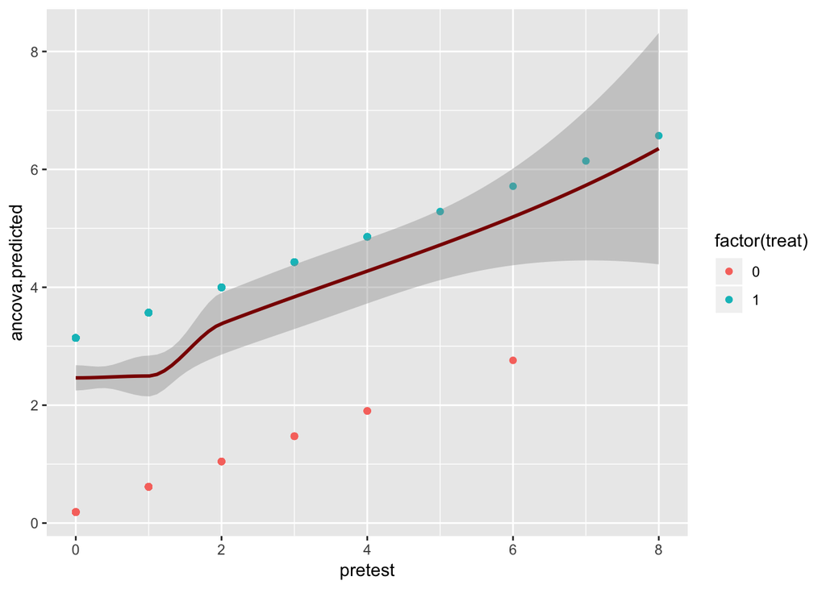

```r
ggplot(csiw, aes(x=pretest, y=ancova.predicted, color=factor(treat))) + geom_point()+geom_smooth(method="loess", color="darkred")
```

#### Assessing linearity

The assignment asks to plot the residuals from the ANCOVA model against the pretest covariate. We will first calculate the residuals and store it in a new column in csiw and then do the plotting

```r
# storing residuals as new column in csiw
csiw$ancova.residuals <- residuals(ancova.model)
```

Now we can plot the required graph. Let us add labels to the x and y axis in this plot

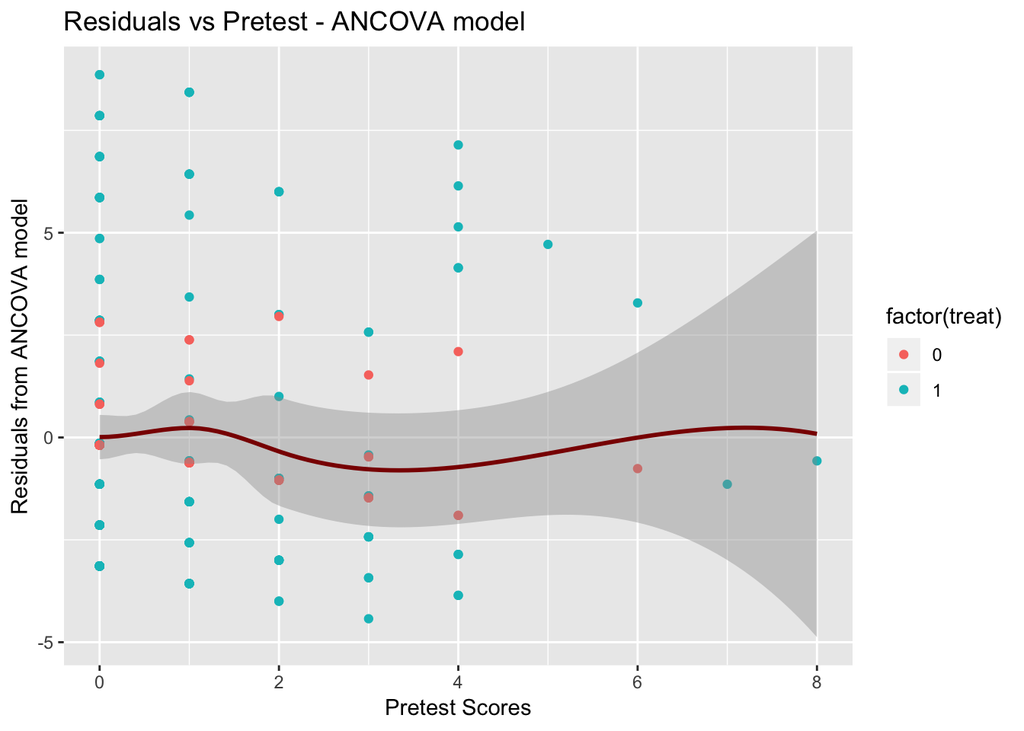

```r
ggplot(csiw, aes(x=pretest, y=ancova.residuals, color=factor(treat))) +geom_point()+geom_smooth(method="loess", color="darkred")+
  xlab("Pretest Scores") + ylab("Residuals from ANCOVA model") + labs(title="Residuals vs Pretest - ANCOVA model")
```

How do we add a quadratic fit? We can create a new variable (pretest.sq) for the pretest variable’s squared value and then replot the graph with the squared variable as the covariate.

```r
csiw$pretest.sq <- csiw$pretest^2
```

Now let us plot the graph again

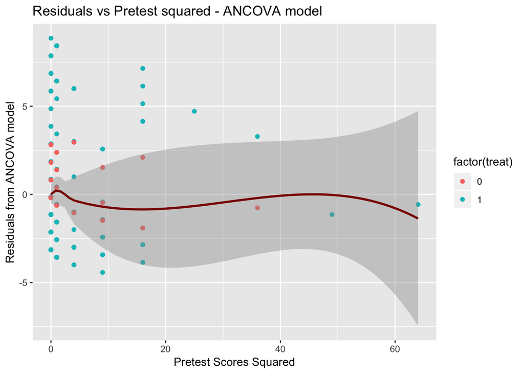

```r
ggplot(csiw, aes(x=pretest.sq, y=ancova.residuals, color=factor(treat))) +geom_point()+geom_smooth(method="loess", color="darkred")+
  xlab("Pretest Scores Squared") + ylab("Residuals from ANCOVA model") + labs(title="Residuals vs Pretest squared - ANCOVA model")
```

#### Quadratic model

Now we have to center the variable `pretest` and create another variable for the squared value of the centered pretest variable.

```r
# We will use the mutate function to create new variables
csiw$pretest.c <- csiw$pretest-mean(csiw$pretest)
csiw$pretest.csq <- (csiw$pretest.c)^2
```

Now let us run the ANCOVA again with the centered variable and its square

```r
quadratic.ancova.model <- lm(posttest ~ treat+pretest.c+pretest.csq, data=csiw)
summ(quadratic.ancova.model)
```

| Observations | 258 |
| --- | --- |
| Dependent variable | posttest |
| Type | OLS linear regression |

| F(3,254) | 15.98 |
| --- | --- |
| R² | 0.16 |
| Adj. R² | 0.15 |

|  | Est. | S.E. | t val. | p |
| --- | --- | --- | --- | --- |
| (Intercept) | 0.53 | 0.41 | 1.29 | 0.20 |
| treat | 2.94 | 0.47 | 6.28 | 0.00 |
| pretest.c | 0.35 | 0.23 | 1.49 | 0.14 |
| pretest.csq | 0.03 | 0.07 | 0.46 | 0.65 |

Standard errors: OLS

Let us look at the predicted values and residual plots of this updated model

```r
csiw$quadratic.ancova.predicted <- predict(quadratic.ancova.model)
csiw$quadratic.ancova.residuals <- residuals(quadratic.ancova.model)
```

Now the plots

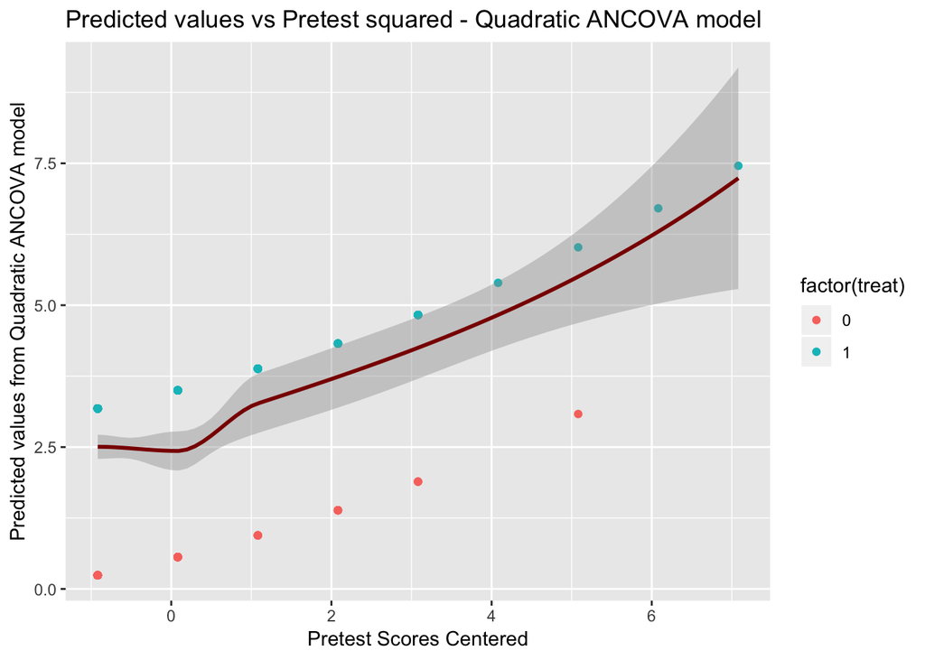

```r
par(mfrow=c(1,2))

ggplot(csiw, aes(x=pretest.c, y = quadratic.ancova.predicted, color=factor(treat))) + geom_point()+
  geom_smooth(method="loess", color="darkred")+  xlab("Pretest Scores Centered") + ylab("Predicted values from Quadratic ANCOVA model") + labs(title="Predicted values vs Pretest squared - Quadratic ANCOVA model")
```

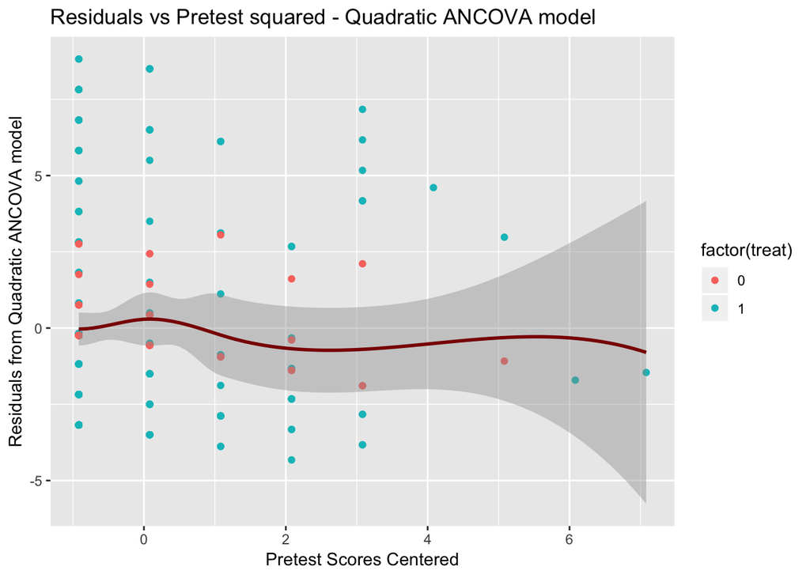

```r
ggplot(csiw, aes(x=pretest.c, y = quadratic.ancova.residuals, color=factor(treat))) + geom_point()+
  geom_smooth(method="loess", color="darkred")+  xlab("Pretest Scores Centered") + ylab("Residuals from Quadratic ANCOVA model") + labs(title="Residuals vs Pretest squared - Quadratic ANCOVA model")
```